# Hypothesis Testing

2024-12-02

## Introduction to Hypotheses Testing

- *Science* is “knowledge or a system of knowledge covering general truths or the operation of general laws especially as obtained and tested through scientific method” (Merriam-Webster 2022).
- The idealized world of the scientific method is question-driven, with the collection and analysis of data determined by the formulation of research questions and the testing of hypotheses.
- *Hypotheses* are tentative assumptions about what the answers to your research questions may be.

## Introduction cont’d

1. Formulate questions: Frame missing knowledge about a phenomenon as research question(s).
2. Literature review: A literature review is an investigation of what existing research says about the phenomenon you are studying. A thorough literature review is essential to identify gaps in existing knowledge you can fill, and to avoid unnecessarily duplicating existing research.
3. Formulate hypotheses: Develop possible answers to your research questions.
4. Collect data: Acquire data that supports or refutes the hypothesis.
5. Test hypotheses: Run tools to determine if the data corroborates the hypothesis.
6. Communicate results: Share your findings with the broader community that might find them useful.

## Scientific method flowchart

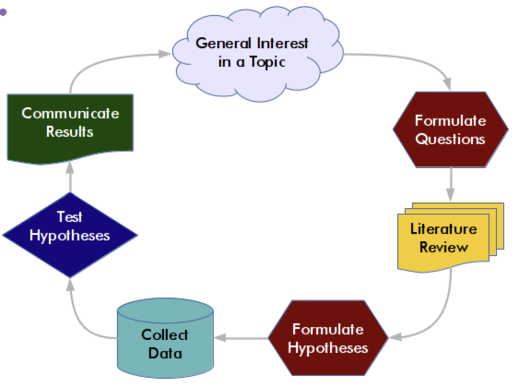

Fig.1

## Null and Alternative Hypotheses

- In scientific inquiry, we are often concerned with whether a factor we are considering (such as taking a specific drug) results in a specific effect (such as reduced recovery time).
- To evaluate whether a factor results in an effect, we will perform an experiment and / or gather data. For example, in a clinical drug trial, half of the test subjects will be given the drug, and half will be given a placebo (something that appears to be the drug but is actually a neutral substance).

## Factor vs. Effect

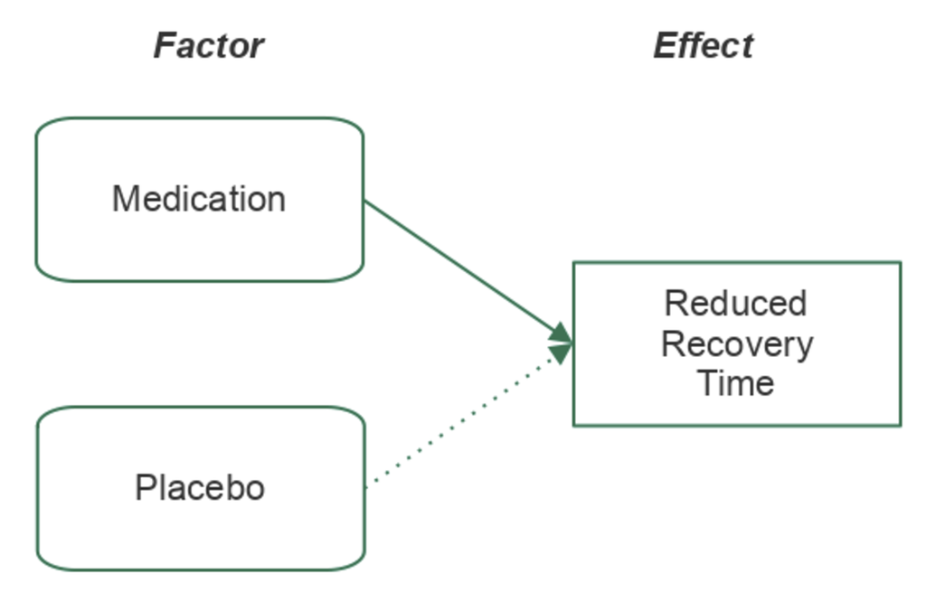

Fig.2

## Introduction Cont’d

Because the data we gather will usually only be a portion (sample) of total possible people or places that could be affected (population), there is a possibility that the sample is unrepresentative of the population. We use a statistical test that considers that uncertainty when assessing whether an effect is associated with a factor.

- Statistical testing begins with an alternative hypothesis (H1) that states that the factor we are considering results in a particular effect. The alternative hypothesis is based on the research question and the type of statistical test being used.
- Because of the problem of induction, we cannot prove our alternative hypothesis. However, under the concept of falsification, we can evaluate the data to see if there is a significant probability that our data falsifies our alternative hypothesis (Wilkinson 2012).

## Introduction Cont’d

- The null hypothesis (Ho) states that the factor has no effect. The null hypothesis is the opposite of the alternative hypothesis. The null hypothesis is what we are testing when we perform a hypothesis test.

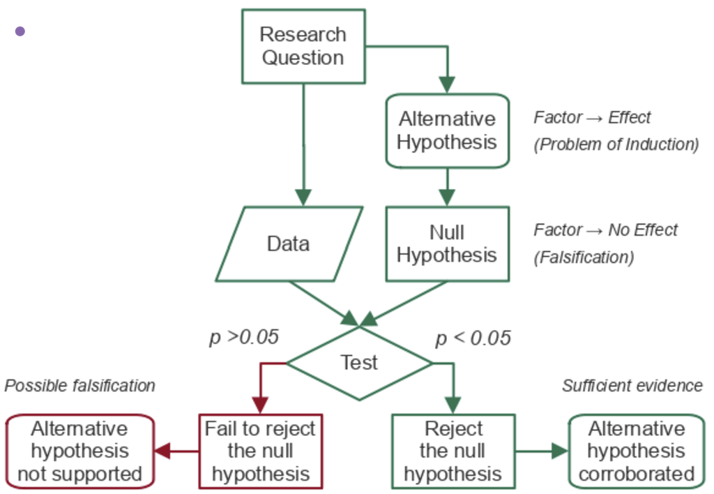

Fig. 3

## Introduction Cont’d

The output of a statistical test like the t-test is a *p-value*. A p-value is the probability that any effects we see in the sampled data are the result of random sampling error (chance).

- If a p-value is greater than the significance level (0.05 for 5% significance) we fail to reject the null hypothesis since there is a significant possibility that our results falsify our alternative hypothesis.
- If a p-value is lower than the significance level (0.05 for 5% significance) we reject the null hypothesis and have corroborated (provided evidence for) our alternative hypothesis.

## Introduction Cont’d

The calculation and interpretation of the p-value goes back to the central limit theorem, which states that random sampling error has a normal distribution.

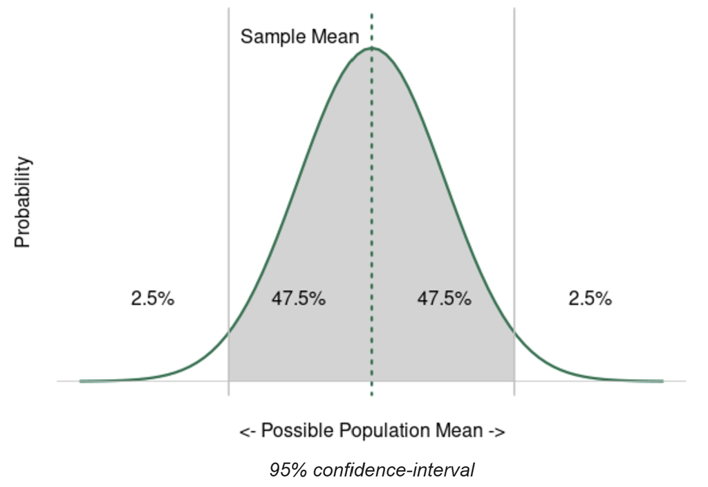

Fig. 4

## Introduction Cont’d

Using our example of a clinical drug trial, if the mean recovery times for the two groups are close enough together that there is a significant possibility (p > 0.05) that the recovery times are the same (falsification), we fail to reject the null hypothesis.

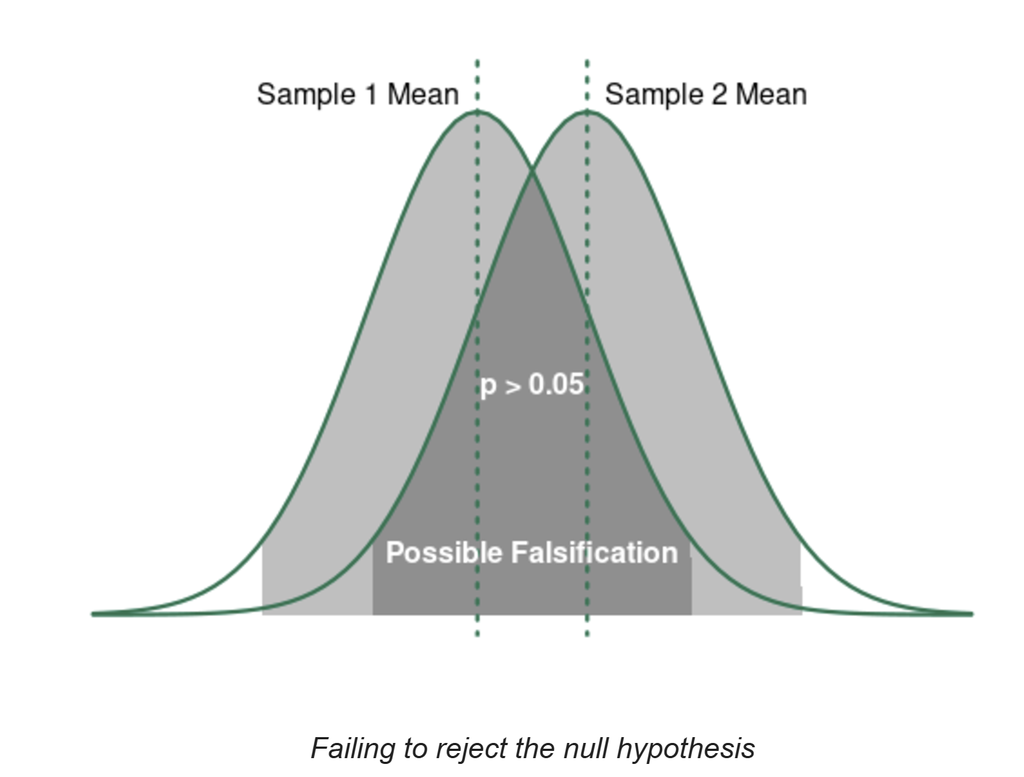

Fig.5

## Introduction Cont’d

However, if the mean recovery times for the two groups are far enough apart that the probability they are the same is under the level of significance (p < 0.05), we reject the null hypothesis and have corroborated our alternative hypothesis.

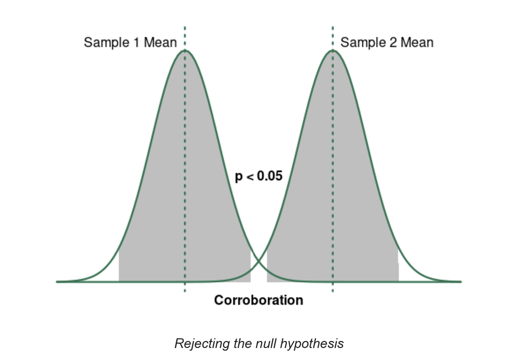

Fig.6

## Introduction Cont’d

*Significance* means that an effect is “probably caused by something other than mere chance” (Merriam-Webster, 2022).

- The significance level `(α)` is the threshold for significance and, by convention, is usually *5%, 10%, or 1%,* which corresponds to *95% confidence*, *90% confidence*, or *99% confidence*, respectively.
- A factor is considered statistically significant if the probability that the effect we see in the data is a result of random sampling error (the p-value) is below the chosen significance level.
- A statistical test is used to evaluate whether a factor being considered is statistically significant (Gallo 2016).

## Type I vs. Type II Errors

Although we are making a binary choice between rejecting and failing to reject the null hypothesis, because we are using sampled data, there is always the possibility that the choice we have made is an error.

There are two types of errors that can occur in hypothesis testing.

- `Type I error` (false positive) occurs when a low p-value causes us to reject the null hypothesis, but the factor does not actually result in the effect.
- `Type II error` (false negative) occurs when a high p-value causes us to fail to reject the null hypothesis, but the factor does actually result in the effect.

## Type I vs. Type II Errors

The numbering of the errors reflects the predisposition of the scientific method to be fundamentally skeptical. Accepting a fact about the world as true when it is not true is considered worse than rejecting a fact about the world that actually is true.

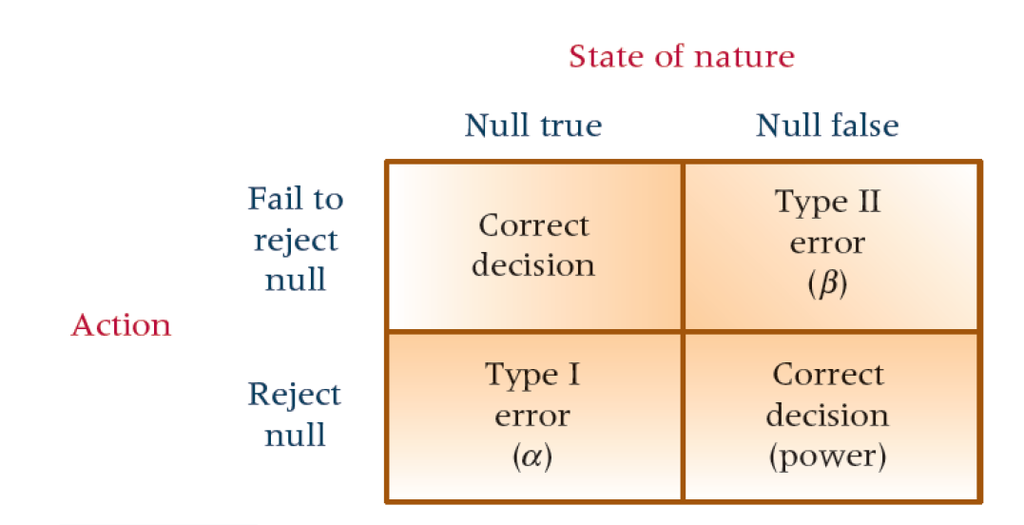

Fig.7

## Statistical Significance vs. Importance

First, statistical significance is distinct from importance. For example, if sampled data reveals a statistically significant difference in cancer rates, that does not mean that the increased risk is important enough to justify expensive mitigation measures.

All statistical results require critical interpretation within the context of the phenomenon being observed. People with different values and incentives can have different interpretations of whether statistically significant results are important.

## Statistical Significance vs. Importance

Second, the use of 95% probability for defining confidence intervals is an arbitrary convention. This creates a good vs. bad binary that suggests a “finality and certitude that are rarely justified.”

Alternative approaches like Beyesian statistics that express results as probabilities can offer more nuanced ways of dealing with complexity and uncertainty (Clayton, 2022).

## Sampling Distributions

## Methods of Sampling: Probability Sampling

- Simple random sampling: each element in the population has an equal chance of being selected.
- Stratified random sampling: the population is first grouped into homogeneous strata and then simple random sampling is performed in each stratum.
- Systematic sampling: where every \(kth\) case after a random start is selected.

## Probability Sampling Cont’d

- Cluster sampling: where the whole population is divided into clusters or groups and subsequently, a random sample is taken from these clusters, all of which are used in the final sample.
- Multi-stage sampling: divides large populations into stages to make the sampling process more practical. A combination of stratified sampling or cluster sampling and simple random sampling is usually used.

## Non-Probability Sampling

- Quota sampling:is a non random sampling technique in which participants are chosen on the basis of predetermined characteristics so that the total sample will have the same distribution of characteristics as the wider population.
- Snowball sampling:is a non random sampling method that uses a few cases to help encourage other cases to take part in the study, thereby increasing sample size.
- Convenience sampling: is selecting participants because they are often readily and easily available.
- Purposive or judgmental sampling:is a strategy in which particular persons or events are selected deliberately in order to provide important information that cannot be obtained from other choices, based on the researcher’s knowledge.

## Strength and Weakness of Sampling Techniques

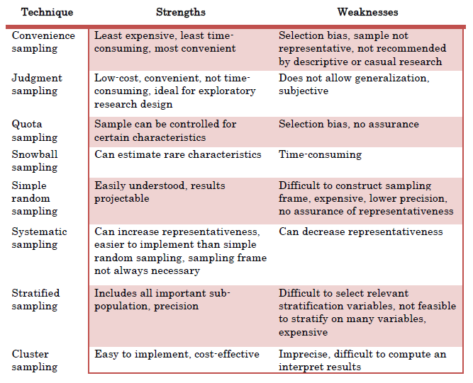

Fig.8

## Sampling Error

- Definition:The discrepancy between the sample estimate and the true population parameter is known as Sampling Error.
- Sampling error is due to sampling variation. A sample statistic used to estimate an unknown population parameter is called an estimate.
- Potential for extreme sampling error is greater when smaller–sized sample are used.
- However, there are cases when larger samples are no guarantee of smaller error.
- Sampling error can include both systematic sampling error and random sampling error.

## Sample Size Determination

- We are always confronted with the question of how large a sample should be drawn.
- The size of the sample depends on various considerations, including population variability, statistical issues, economic factors, availability of participants and the importance of the problem.
- In inferential statistics, the sample size required depends on how big a difference between two groups you want to be able to detect. With large sample sizes, small differences can be detected.

## Sample Size Determination

- If the sample size is sufficiently large, virtually any population difference will result in statistical significance.
- On the other hand, the smaller the sample size, the larger must be the population differences to achieve statistical significance.
- Several statistical formulas are available for determining sample size.
- The Cochran formula allows you to calculate an ideal sample size given a desired level of precision, desired confidence level, and the estimated proportion of the attribute present in the population.

## Sample Size Formula

- Cochran formula for large population is given as: \[ n= \dfrac{Z_{\alpha /2}^2*p(1-p)}{e^2} \] where:
- \(n\): Required sample size,
- \(e\): Desired level of precision (i.e. the margin of error),
- \(p\): Estimated proportion of the population which has the attribute in question,
- \(Z_{\alpha /2}^2\): Z-score for the desired confidence level (e.g., 1.96 for 95% confidence).

## Sample Size Formula

- Used when the to estimate the mean outcome is continuous (e.g., blood pressure, cholesterol level).

\[ n= \dfrac{(Z_{\alpha /2}*\sigma)^2}{e^2} \] where:

- \(n\): Required sample size.
- \(e\): Desired level of precision (i.e. the margin of error)
- \(\sigma\): Estimated standard deviation of the outcome.
- \(Z_{\alpha /2}^2\): Z-score for the desired confidence level (e.g., 1.96 for 95% confidence).

## Sample Size Formula

- Used when comparing means between two groups (e.g., treatment vs. control).

\[ n= 2\left(\dfrac{Z_{\alpha /2}+ Z_{\beta}}{\triangle \sigma}\right)^2 \]

- \(n\): Required sample size per group.
- \(Z_{\alpha /2}\): Z-score for the desired confidence level.
- \(Z_{\beta}\) : Z-score for desired power (e.g., 0.84 for 80% power).
- \(\triangle\): Minimum clinically significant difference between groups.
- \(\sigma\): Estimated standard deviation.

## Sample Size Formula

- Used to compare proportions between two groups (e.g., event rates).

\[ n= \dfrac{\left(Z_{\alpha /2}\sqrt(2p(1-p))+ Z_{\beta}\sqrt(p_1(1-p_1)+p_2(1-p_2))\right)^2}{(p_1-p_2)^2} \]

- \(p_1\): Proportion in group 1.
- \(p_2\): Proportion in group 2.
- \(p\): Pooled proportion:\(\frac{p_1+p_2}{2}\)

## Sample Size Formula

- Used when studying time-to-event outcomes (e.g., survival rates).

\[ n= \dfrac{2\left(Z_{\alpha /2}+ Z_{\beta}\right)^2}{(\ln(HR))^2 *p(1-p)} \]

- \(HR\): Hazard ratio of interest.
- \(p\): Proportion of participants expected to experience the event.